# 511-2017-09-27-neurochemistry-II

2017-09-27 14:21:41

## Today's Topics

- Neurochemistry
  - How neurons talk to one another

[figure not shown]

## How to stop your prey

| Substance | Effect |
| --- | --- |
| Japanese pufferfish toxin | Blocks voltage-gated \(Na^+\) channels |
| Black widow spider venom | Accelerates presynaptic ACh release |
| Botulinum toxin | Prevents ACh vesicles from binding presynaptically |
| Sarin nerve gas | Impedes ACh breakdown by AChE |
| Pesticides | Impedes AChE |
| Tetanus toxin | Blocks release of GABA, glycine |

## Monoamine Song

[video not shown]

https://en.wikipedia.org/wiki/Mah_Nà_Mah_Nà

## Monoamine Song

￼Monoamines, do-do do do-do  
Monoamines, do do do-do  
Monoamines, do do do do-do do do-do do do-do do do do do-do do

## Monoamine Song

￼Monoamines, do-pa-mine is one  
Monoamines, norepi, too  
Monoamines, sero-tonin e-pinephrine, dop-a- mine, nor-epinephrine, melatonin, whoo!

## Monoamine Song

Monoamines, mod-u-late neurons  
Monoamines, throughout the brain  
Monoamines, keep people happy, brains snappy, not sleepy, not sappy, do-do do-do do-do do

## Monoamine NTs

| Family | Neurotansmitter |
| --- | --- |
| Monoamines | Dopamine (DA) |
|  | Norepinephrine (NE)/Noradrenaline (NAd) |
|  | Epinephrine (Epi)/Adrenaline (Ad) |
|  | Serotonin (5-HT) |
|  | Melatonin |
|  | Histamine |

## Information processing

- Point-to-point
  - One sender, small number of recipients
  - Glu, GABA
- Broadcast
  - One sender, widespread recipients
  - DA, NE, 5-HT, melatonin, histamine
  - Often involved in psychiatric conditions [(Costa, Brookes, and Hennig 2000)](http://doi.org/10.1136/gut.47.suppl_4.iv15)]

## Information processing

- Need to know
  - NT, where projecting, type of receptor to predict function

## Dopamine

- Released by
  - Substantia nigra -> striatum, *meso-striatal projection*
  - Ventral tegmental area (VTA) -> nucleus accumbens, ventral striatum, hippocampus, amygdala, cortex; *meso-limbo-cortical projection*

## Dopamine Anatomy

[figure not shown]

http://thebrain.mcgill.ca/flash/a/a_03/a_03_cl/a_03_cl_que/a_03_cl_que_1a.gif

## DA Disruption linked to

- Parkinson's Disease (mesostriatal)
  - DA agonists treat (agonists facilitate/increase transmission)
- ADHD (mesolimbocortical)
- Schizophrenia (mesolimbocortical)
  - DA antagonists treat – [Dopamine hypothesis of schizophrenia](https://en.wikipedia.org/wiki/Dopamine_hypothesis_of_schizophrenia)
- Addiction (mesolimbocortical) – [reward system](https://en.wikipedia.org/wiki/Reward_system)

## DA Inactivated by

- Dopamine transporter (DAT) and chemical breakdown

http://www.scholarpedia.org/article/Dopamine_anatomy#Dopamine_receptors

## Dopamine receptors

| Type | Receptor | Comments |
| --- | --- | --- |
| Metabotropic | \(D_1\)-like (\(D_1\) and \(D_5\)) | more prevalent |
|  | \(D_2\)-like (\(D_2\), \(D_3\), \(D_4\)) | target of many antipsychotics |

## Norepinephrine (NE)

- Released by
  - *[locus coeruleus](http://www.scholarpedia.org/article/Locus_coeruleus)* in pons
  - postganglionic sympathetic neurons onto target tissues
- Role in arousal, mood, eating, sexual behavior
- Monoamine oxidase inhibitors (MAOIs)
  - inactivate monoamines in neurons, astrocytes
  - [MAOIs](https://en.wikipedia.org/wiki/Monoamine_oxidase_inhibitor) increase NE, DA
  - Treatment for depression

## NE Anatomy

[figure not shown]

https://www.dartmouth.edu/~rswenson/NeuroSci/figures/Figure_9_files/image002.jpg

## NE receptors

| Type | Receptor | Comments |
| --- | --- | --- |
| Metabotropic | \(\alpha\) (1,2) | antagonists treat anxiety, panic |
|  | \(\beta\) (1,2,3) | 'beta blockers' in cardiac disease |

|  | Epinephrine | Norepinephrine |
| --- | --- | --- |
| Chemical diff | + methyl group |  |
| Released | Mostly from adrenal medulla | adrenal medulla + symp NS |
| Targets | broader | narrower |
| Therapeutic | treat allergic reactions | increase blood pressure |

## Serotonin (5-HT)

- Released by *raphe nuclei* in brainstem
- Role in mood, sleep, eating, pain, nausea, cognition, memory
- Modulates release of other NTs
- Most of body's 5-HT regulates *digestion* via *enteric nervous system*

## Enteric nervous system

- ~ 500 M nerves (> spinal cord), aka "second brain"
- Ennervated by symp and parasymp, but can function autonomously
- Interface b/w microbiome and CNS [(Lima-Ojeda, Rupprecht, and Baghai 2017)](http://dx.doi.org/10.3389/fpsyt.2017.00153)

## 5-HT anatomy

[figure not shown]

https://www.dartmouth.edu/~rswenson/NeuroSci/figures/Figure_9_files/image002.jpg

## 5-HT receptors

- Seven families (5-HT 1-7) with 14 types
- All but one metabotropic

## 5-HT clinical significance

- Ecstasy (MDMA) affects serotonin
- So does lysergic acid diethylamide (LSD)
- Fluoxetine (Prozac)
  - *Selective Serotonin Reuptake Inhibitor (SSRI)*
  - Treats depression, panic, eating disorders, others
- 5-HT3 receptor antagonists are anti-mimetics used in treating nausea

## Melatonin

- Released by pineal gland

[figure not shown]

http://www.vivo.colostate.edu/hbooks/pathphys/endocrine/otherendo/pinealgland.jpg

## Histamine

- Released by hypothalamus, projects to whole brain
- Metabotropic receptors
- Role in arousal/sleep regulation
- In body, part of immune response

## Targets of psychotropic drugs

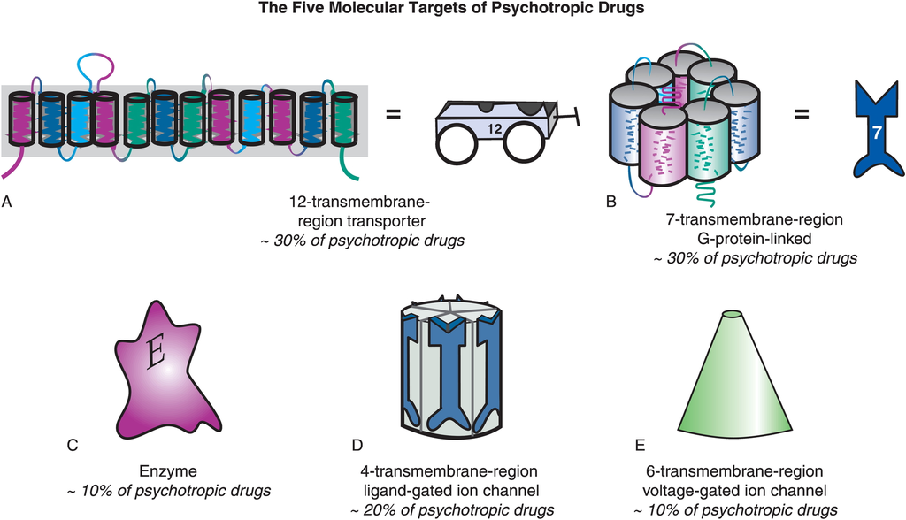

https://stahlonline.cambridge.org/essential_4th_chapter.jsf?page=chapter2_summary.htm&name=Chapter%202&title=Summary

## Monoamine synthesis network

[figure not shown]

[(Ng et al. 2015)](http://doi.org/10.1038/nrneurol.2015.172)

## Others

- Gases
  - *Nitric Oxide (NO)*, *carbon monoxide (CO)*
    - Diffuse over larger area than typical NTs
- Neuropeptides
  - *Substance P* and *endorphins* (endogenous morphine-like compounds) have role in pain
  - *Orexin/hypocretin*, project from lateral hypothalamus across brain, regulates appetite, arousal
  - *Cholecystokinin (CCK)* stimulates digestion

## Others

- Purines
  - *Adenosine* (inhibited by caffeine)
- Others
  - *Anandamide* (activates endogenous cannabinoid receptors)

## Types of chemical communication

- *Neurocrine*
  - ￼Sending cell -> Receiving cell
- *Autocrine*
  - Sending cell -> itself
  - e.g., presynaptic autoreceptors
- *Paracrine*
  - Sending cell -> neighboring cells
  - NO and CO NTs

## Types of chemical communication

- *Endocrine*
  - Sending cell -> many cells elsewhere in body
- *Pheromone*
  - Sending cell -> other animals of same species
- *Allomone*
  - Sending cell -> cells in other species

## References

Costa, M, S J Brookes, and G W Hennig. 2000. “Anatomy and Physiology of the Enteric Nervous System.” *Gut* 47 Suppl 4 (December): iv15–9; discussion iv26. doi:10.1136/gut.47.suppl\_4.iv15.

Lima-Ojeda, Juan M, Rainer Rupprecht, and Thomas C Baghai. 2017. “‘I Am I and My Bacterial Circumstances’: Linking Gut Microbiome, Neurodevelopment, and Depression.” *Front. Psychiatry* 8 (22~aug): 153. doi:10.3389/fpsyt.2017.00153.

Ng, Joanne, Apostolos Papandreou, Simon J Heales, and Manju A Kurian. 2015. “Monoamine Neurotransmitter Disorders–clinical Advances and Future Perspectives.” *Nat. Rev. Neurol.* 11 (10): 567–84. doi:10.1038/nrneurol.2015.172.